# MOOCs Analysis

Tarun Agrawal

1/7/2022

### Description of the Variables

**Degree all** - This column represents the number of people a learner reached out on the discussion forum

**Strength all** - This column represent the many times a learner reached out on the discussion forum

**Treatment** - This column tells if the student was a part of the experiment or the control group. Here, *experiment* means that the student received the treatment and *control* means that the student did not receive the treatment.

**useSRLUI** - This column tells us if the student actually interacted with the Self Regulatory Learner User Interface (SRLUI) or not. Here 1 means that the student interacted, and 0 means he did not interact with the treatment.

**Grades** - This column tells us Grades obtained by the student

**drop_out** - This columns informs us if the student dropped out of the course or not.

**survival_days** - This columns informs us about the number of days student was a part of the course

### Motivating Questions and Ideas for Analysis

**1.** What was the impact of treatment on the learning outcomes, that is grades, drop outs, and survival days?

**2.** Identifying the variables(including grades and survival days with others) that determines if a student will drop out of the course, and using the logistic regression to predict the same based on useful variables.

**3** Identify the relation between the number of times a learned reached out on the discussion forum/ number of people learned out to, and the learning outcomes, and applying linear regression model to predict the grade, and survival days of student using the significant variables.

### Importing and Cleaning the data

This code block installs the required libraries, and load the data file into the environment, performs some basic checks and filters the data to get it in the final that could be used for analysis.

```r
library(tidyverse)
library(fastDummies)
data<-read_csv("/Users/tarunagrawal/Desktop/Spring Assistantship/EDA Job/SRLUIBeta1_fake_data.csv")
data1<-data[,c(5,12,19,20,21,22,23,24)]
data2<-data[,c(5,12,19,20,21,22,23,24)]

# Gathering basic insights about the data to make sure it is correct to the best of our knowledge
summary(data2)
```

```
##    degree_all      strength_all     treatment            useSRLUI
##  Min.   : 1.000   Min.   :  1.00   Length:322         Min.   :0.0000
##  1st Qu.: 2.250   1st Qu.:  3.00   Class :character   1st Qu.:0.0000
##  Median : 5.000   Median :  7.00   Mode  :character   Median :0.0000
##  Mean   : 6.792   Mean   : 11.48                      Mean   :0.4689
##  3rd Qu.: 9.000   3rd Qu.: 14.00                      3rd Qu.:1.0000
##  Max.   :41.000   Max.   :123.00                      Max.   :1.0000
##      Grade         education            drop_out      survival_days
##  Min.   :  0.00   Length:322         Min.   :0.0000   Min.   :  4.00
##  1st Qu.: 35.00   Class :character   1st Qu.:0.0000   1st Qu.: 63.00
##  Median : 74.00   Mode  :character   Median :0.0000   Median : 82.00
##  Mean   : 61.90                      Mean   :0.2081   Mean   : 75.34
##  3rd Qu.: 85.75                      3rd Qu.:0.0000   3rd Qu.: 91.00
##  Max.   :100.00                      Max.   :1.0000   Max.   :113.00
```

```r
# Checking the data type of each variable, and get it in the correct form if needed.
str(data2)
```

```
## tibble [322 × 8] (S3: tbl_df/tbl/data.frame)
##  $ degree_all   : num [1:322] 14 15 13 1 21 9 13 10 5 6 ...
##  $ strength_all : num [1:322] 26 53 14 1 42 24 21 15 8 7 ...
##  $ treatment    : chr [1:322] "experiment" "control" "control" "experiment" ...
##  $ useSRLUI     : num [1:322] 1 0 0 1 1 0 1 0 1 0 ...
##  $ Grade        : num [1:322] 49 97 27 14 65 86 95 79 91 85 ...
##  $ education    : chr [1:322] "other" "undergrad" "undergrad" "undergrad" ...
##  $ drop_out     : num [1:322] 0 0 0 1 0 0 0 0 0 0 ...
##  $ survival_days: num [1:322] 92 84 99 74 90 97 91 88 61 89 ...
```

```r
# Changing the data types for required variables
data2$useSRLUI<-as.factor(data2$useSRLUI)
data2$drop_out<-as.factor(data2$drop_out)

# Other Basic checks on the data
# Check for the NA values in the data set
which(is.na(data1)) # No NA values  found
```

```
## integer(0)
```

```r
# Check for the possible basic errors of the values in the degree_all and strength_all columns.
which(data1$degree_all>data1$strength_all) # Appears to be correct
```

```
## integer(0)
```

```r
# Check if all students intended to use SRLUI did it or not
data1 %>% filter(treatment=="experiment" & useSRLUI==0)
```

```
## # A tibble: 21 × 8
##    degree_all strength_all treatment  useSRLUI Grade education         drop_out
##         <dbl>        <dbl> <chr>         <dbl> <dbl> <chr>                <dbl>
##  1          9           14 experiment        0    94 undergrad                0
##  2          6            7 experiment        0    59 undergrad                0
##  3          1            1 experiment        0    42 other                    0
##  4         16           53 experiment        0    87 undergrad                0
##  5          3            3 experiment        0    24 other                    1
##  6         10           15 experiment        0    71 other                    0
##  7          6            7 experiment        0    91 high_sch or under        0
##  8          1            1 experiment        0    93 other                    0
##  9          9           11 experiment        0    81 undergrad                0
## 10          2            2 experiment        0     0 undergrad                1
## # … with 11 more rows, and 1 more variable: survival_days <dbl>
```

```r
# Not all intended students used SRLUI
```

#### Part 1:

This part explores **the impact of treatment on the learning outcomes, that is grades, drop outs, and survival days.**

**Note:** *The analysis has been done based on if student interacted with the treatment or not, and not on the basis of the intent to treat. It is clear from previous analysis that two are not the same*

#### Impact on grades

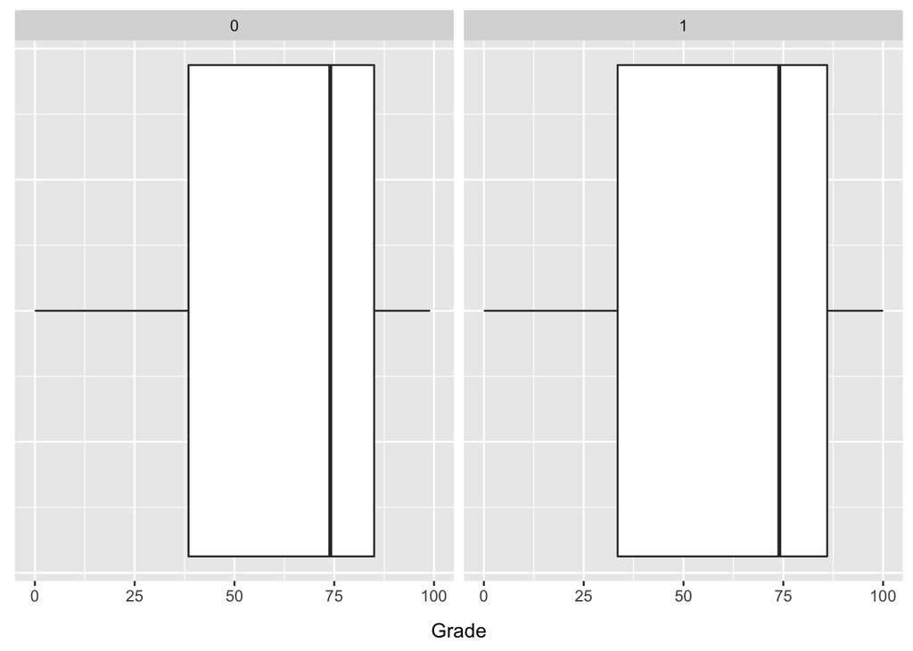

```r
# Create a box plot to identify the impact of treatment on grades

ggplot(data2) + geom_boxplot(mapping = aes(x=Grade)) + facet_wrap("useSRLUI") + theme(axis.title.x =element_text(margin = margin(t = 10, r = 0, b = 0, l = 0)), axis.title.y=element_text(margin = margin(t = 0, r = 15, b = 0, l = 0)), axis.text.y = element_blank(), axis.ticks.y = element_blank())
```

```r
# Find the values of quantiles, and mean to get exact values for comparison
data_NI<- data2 %>% filter(useSRLUI=="0")
data_I<- data2 %>% filter(useSRLUI=="1")
quantile(data_NI$Grade, probs = seq(0,1,0.25))
```

```
##   0%  25%  50%  75% 100%
##  0.0 38.5 74.0 85.0 99.0
```

```r
quantile(data_I$Grade, probs = seq(0,1,0.25))
```

```
##    0%   25%   50%   75%  100%
##   0.0  33.5  74.0  86.0 100.0
```

```r
# Mean for the students who did not interact with treatment
mean(data_NI$Grade)
```

```
## [1] 61.90058
```

```r
# Mean for the students who interacted with treatment
mean(data_I$Grade)
```

```
## [1] 61.90066
```

As is evident from the plot, and the values that the treatment did not have any significant impact on the grades of the students. The numbers for the quantiles, and the average value of grades for the two groups are close to each other.

#### Impact on drop out

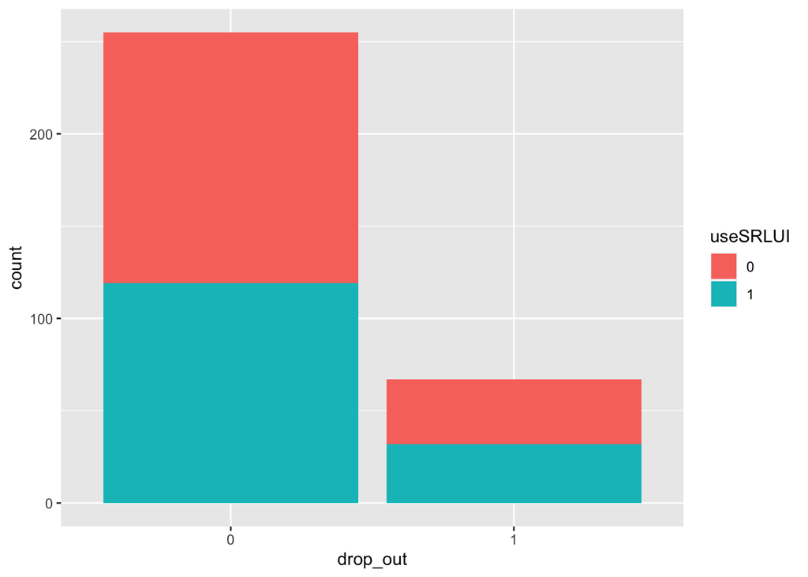

```r
# Create a bar plot for number of drop outs in both the categories
ggplot(data2) + geom_bar(mapping = aes(x=drop_out, fill=useSRLUI))
```

```r
# Ratio of students who dropped out for those who did not interacted with treatment
nrow(data_NI %>% filter(drop_out==1))/nrow(data_NI)
```

```
## [1] 0.2046784
```

```r
# Ratio of students who dropped out for those who interacted with treatment
nrow(data_I %>% filter(drop_out==1))/nrow(data_I)
```

```
## [1] 0.2119205
```

It can be concluded from the graphs, and the ratio that the treatment did not have an significant impact on the drop out rate.

#### Impact on survival days

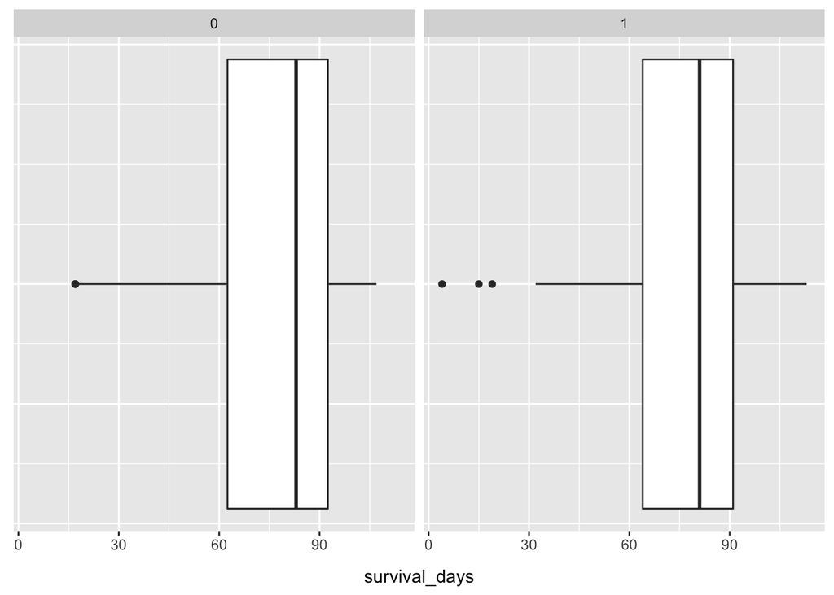

```r
# Create a box plot to identify the impact of treatment on survival days

ggplot(data2) + geom_boxplot(mapping = aes(x=survival_days)) + facet_wrap("useSRLUI") + theme(axis.title.x =element_text(margin = margin(t = 10, r = 0, b = 0, l = 0)), axis.title.y=element_text(margin = margin(t = 0, r = 15, b = 0, l = 0)), axis.text.y = element_blank(), axis.ticks.y = element_blank())
```

```r
quantile(data_NI$survival_days, probs = seq(0,1,0.25))
```

```
##    0%   25%   50%   75%  100%
##  17.0  62.5  83.0  92.5 107.0
```

```r
quantile(data_I$survival_days, probs = seq(0,1,0.25))
```

```
##   0%  25%  50%  75% 100%
##    4   64   81   91  113
```

```r
# Mean for the students who did not interact with treatment
mean(data_NI$survival_days)
```

```
## [1] 75.22222
```

```r
# Mean for the students who interacted with treatment
mean(data_I$survival_days)
```

```
## [1] 75.48344
```

The box plot suggests the presence of outliers in both the categories. As is evident from the box plots, quantiles and mean, the treatment did not have a significant impact on survival days as well.

#### Part 2:

This part **Identify the variables(including grades and survival days with others) that determines if a student will drop out of the course, and using the logistic regression to predict the same based on useful variables.**

**Note:**

*1. All the students are taken into account irrespective of the treatment group. This is because the treatment did not had any significant impact on the outcomes as visible in previous parts.*

*2. Also the linearity assumptions such as normality are assumed to be true/checked using the residual plots plotted later.*

*3. The outliers in the survival_days have not been removed.*

```r
# Check the multi-collinearity
data_correlation<-as.matrix(data1 %>% select(c(degree_all,strength_all,Grade,survival_days)))
cor(data_correlation)
```

```
##               degree_all strength_all     Grade survival_days
## degree_all     1.0000000    0.9188781 0.2573954     0.2761414
## strength_all   0.9188781    1.0000000 0.2158183     0.2653324
## Grade          0.2573954    0.2158183 1.0000000     0.4713093
## survival_days  0.2761414    0.2653324 0.4713093     1.0000000
```

```r
# This suggests the presence of high correlation between degree_all and strength_all. Hence only one of the two can be used for logistic regression model.

# Logistic Regression for the chances of drop out

set.seed(3)
split = sample(1:nrow(data1), nrow(data1)*0.80)
train = data1[split,]
test = data1[-split,]

# Using only strength_all
logit1<-glm(train$drop_out~., data = train[,c(2,5,8)], family = "binomial")
summary(logit1)
```

```
##
## Call:
## glm(formula = train$drop_out ~ ., family = "binomial", data = train[,
##     c(2, 5, 8)])
##
## Deviance Residuals:
##      Min        1Q    Median        3Q       Max
## -2.07426  -0.07011  -0.02068  -0.00602   2.04432
##
## Coefficients:
##               Estimate Std. Error z value Pr(>|z|)
## (Intercept)   11.17976    2.41109   4.637 3.54e-06 ***
## strength_all   0.06771    0.03705   1.828   0.0676 .
## Grade         -0.12790    0.02598  -4.923 8.51e-07 ***
## survival_days -0.11782    0.02812  -4.190 2.79e-05 ***
## ---
## Signif. codes:  0 '***' 0.001 '**' 0.01 '*' 0.05 '.' 0.1 ' ' 1
##
## (Dispersion parameter for binomial family taken to be 1)
##
##     Null deviance: 256.094  on 256  degrees of freedom
## Residual deviance:  46.798  on 253  degrees of freedom
## AIC: 54.798
##
## Number of Fisher Scoring iterations: 8
```

```r
# Using only degree_all
logit2<-glm(train$drop_out~., data = train[,c(1,5,8)], family = "binomial")
summary(logit2)
```

```
##
## Call:
## glm(formula = train$drop_out ~ ., family = "binomial", data = train[,
##     c(1, 5, 8)])
##
## Deviance Residuals:
##      Min        1Q    Median        3Q       Max
## -2.10649  -0.05683  -0.01693  -0.00453   2.11570
##
## Coefficients:
##               Estimate Std. Error z value Pr(>|z|)
## (Intercept)   11.52118    2.53687   4.541 5.59e-06 ***
## degree_all     0.14217    0.06659   2.135   0.0328 *
## Grade         -0.13348    0.02788  -4.788 1.68e-06 ***
## survival_days -0.12396    0.02978  -4.163 3.14e-05 ***
## ---
## Signif. codes:  0 '***' 0.001 '**' 0.01 '*' 0.05 '.' 0.1 ' ' 1
##
## (Dispersion parameter for binomial family taken to be 1)
##
##     Null deviance: 256.094  on 256  degrees of freedom
## Residual deviance:  45.224  on 253  degrees of freedom
## AIC: 53.224
##
## Number of Fisher Scoring iterations: 9
```

```r
# AIC for Case 2 is lower, hence we would use degree_all.

predicted<-predict(logit2, test, type="response")
for (i in 1:length(predicted)) {
  if(predicted[i]>=0.05){
    predicted[i]=1
  } else
  {predicted[i]=0
    }
}

length(which(predicted==test$drop_out))
```

```
## [1] 61
```

The given logistic model predicted the correct outcome in 61 out of 65 test cases. Based on this, we can assume that degree_all, grade, and survival_days can be used as predictors for the drop out rates. The prediction would improve as the sample size would be increased.

#### Part 3:

This part **identifies the relation between the number of times a learned reached out on the discussion forum/ number of people learned out to, and the grades and survival days, and applying linear regression to develop a model to predict the grade, and survival days of student using the significant variables.**

#### Grades

```r
# Linear Model for the prediction of Grades
reg<-lm(Grade~., data = data1[,c(1,5,8)]) # Only using 1 and 5 significantly reduced the adjusted R-squared Value
summary(reg)
```

```
##
## Call:
## lm(formula = Grade ~ ., data = data1[, c(1, 5, 8)])
##
## Residuals:
##     Min      1Q  Median      3Q     Max
## -69.938 -19.495   6.578  18.444  62.537
##
## Coefficients:
##               Estimate Std. Error t value Pr(>|t|)
## (Intercept)    9.80870    5.55400   1.766  0.07834 .
## degree_all     0.69406    0.25594   2.712  0.00705 **
## survival_days  0.62882    0.07372   8.530 6.01e-16 ***
## ---
## Signif. codes:  0 '***' 0.001 '**' 0.01 '*' 0.05 '.' 0.1 ' ' 1
##
## Residual standard error: 27.24 on 319 degrees of freedom
## Multiple R-squared:  0.2397, Adjusted R-squared:  0.2349
## F-statistic: 50.27 on 2 and 319 DF,  p-value: < 2.2e-16
```

```r
predict(reg,test)
```

```
##        1        2        3        4        5        6        7        8
## 72.64862 58.42322 78.13585 73.90625 78.93678 85.27216 57.99014 64.26028
##        9       10       11       12       13       14       15       16
## 24.96552 53.95627 51.63674 47.69173 58.35798 49.55456 66.03425 65.27495
##       17       18       19       20       21       22       23       24
## 67.85545 29.43247 21.88668 56.10369 62.32660 76.74773 69.04784 72.45289
##       25       26       27       28       29       30       31       32
## 69.80714 67.09615 68.61476 67.14338 73.90625 31.08156 38.36637 39.42827
##       33       34       35       36       37       38       39       40
## 80.62749 28.93414 31.94773 76.48676 62.82493 80.67472 92.97205 66.53258
##       41       42       43       44       45       46       47       48
## 55.86633 66.16474 50.18338 72.15029 71.56310 53.91464 69.11308 53.71891
##       49       50       51       52       53       54       55       56
## 74.07837 74.46982 33.76893 49.61981 40.75115 73.53841 69.17833 69.11308
##       57       58       59       60       61       62       63       64
## 66.79355 54.28249 77.11557 60.30967 60.57064 67.92070 90.00008 30.06128
##       65
## 57.62229
```

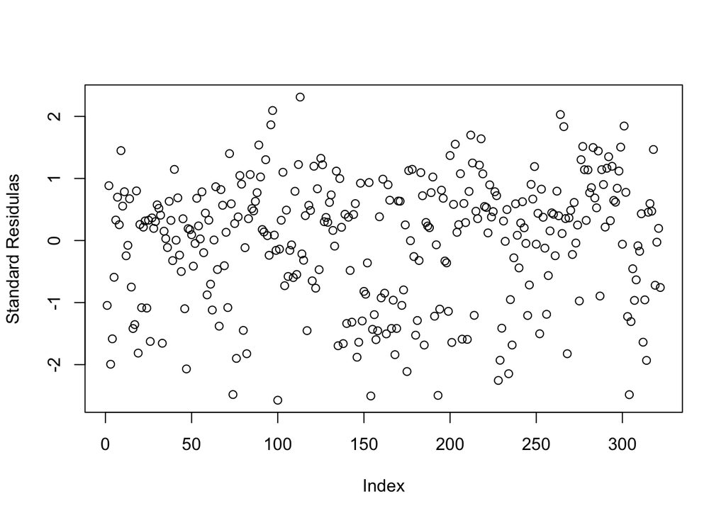

```r
plot(rstandard(reg),ylab = "Standard Residulas")
```

The linear model suggests that the degree_all and survival_days is a useful predictor for Grades in case of using linear models.But the Adjusted R-squared value is low, which implies that the linear model may not be the best to use in this case. This can be verified from the plot of standard residuals which shows large error in predicted values.

#### Survival Days

```r
# Linear Model for the Survival Days
reg1<-lm(survival_days~., data = data1[,c(1,5,8)])
summary(reg1)
```

```
##
## Call:
## lm(formula = survival_days ~ ., data = data1[, c(1, 5, 8)])
##
## Residuals:
##     Min      1Q  Median      3Q     Max
## -59.100 -11.014   4.389  11.929  41.856
##
## Coefficients:
##             Estimate Std. Error t value Pr(>|t|)
## (Intercept) 53.15341    2.40269   22.12  < 2e-16 ***
## degree_all   0.57565    0.17446    3.30  0.00108 **
## Grade        0.29534    0.03463    8.53 6.01e-16 ***
## ---
## Signif. codes:  0 '***' 0.001 '**' 0.01 '*' 0.05 '.' 0.1 ' ' 1
##
## Residual standard error: 18.67 on 319 degrees of freedom
## Multiple R-squared:  0.2478, Adjusted R-squared:  0.2431
## F-statistic: 52.55 on 2 and 319 DF,  p-value: < 2.2e-16
```

```r
predict(reg1,test)
```

```
##         1         2         3         4         5         6         7         8
##  86.09593  63.44513  88.05811  83.43790  82.84722  93.17885  77.28090  89.10423
##         9        10        11        12        13        14        15        16
##  55.50108  81.47572  56.03165  82.50681  59.91611  54.30471  78.78763  74.68296
##        17        18        19        20        21        22        23        24
##  75.55395  61.09746  75.56898  82.00629  73.16120  80.11406  77.04566  77.28090
##        25        26        27        28        29        30        31        32
##  79.08297  69.67726  79.65862  72.03478  87.57262  60.41663  57.22803  53.72906
##        33        34        35        36        37        38        39        40
##  83.48297  56.63735  56.96274  70.13271  82.64204  97.65398 105.99337  79.40836
##        41        42        43        44        45        46        47        48
##  87.52754  80.82494  56.37207  83.11251  81.77105  89.01925  79.68867  76.66017
##        49        50        51        52        53        54        55        56
##  58.14409  82.27158  56.09176  79.09800  54.30471  88.98920  79.08297  78.21198
##        57        58        59        60        61        62        63        64
##  80.23427  85.23997  83.42287  75.25861  84.05862  81.74100  95.76175  55.48606
##        65
##  79.58349
```

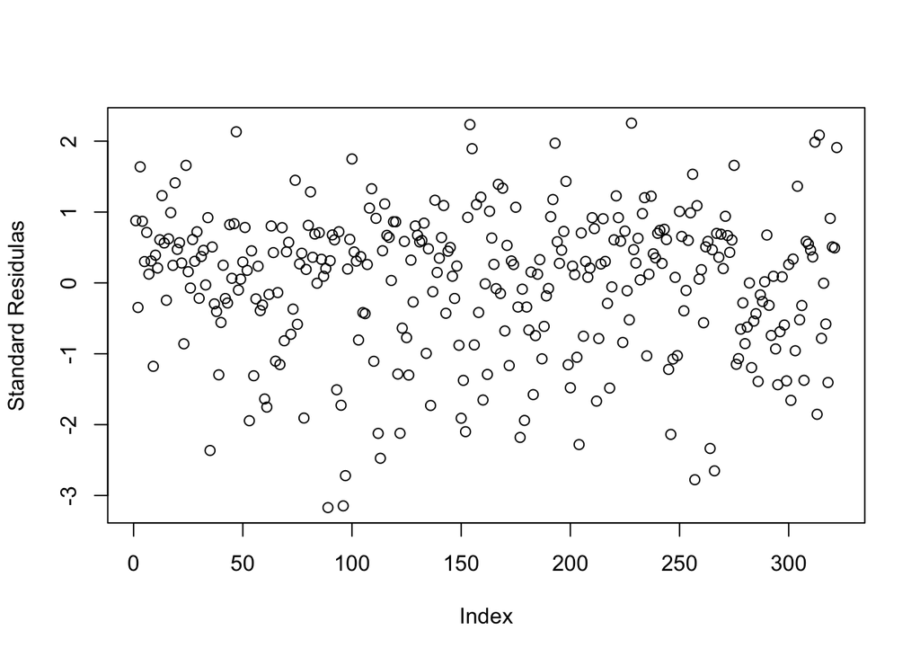

```r
plot(rstandard(reg1),ylab = "Standard Residulas")
```

The linear model suggests that the degree_all and grade is a useful predictor for survival days in case of using linear models. Since the Adjusted R-squared value is low, linear model may not be the best to use in this case. This can be verified from the plot of studentised residuals which shows large error in predicted values.

### Conclusion

1. The treatment didn’t result in a significant change in either of the learning outcome.
2. degree_all, grade, and survival_days turned out to be good predictors for the chance of a student dropping out.
3. The linear model suggested using degree_all, and survival days for the prediction of Grades but was not that effective due to low adjusted R squared. It also suggested the same for predicting survival days using degree_all and Grades as predictor variables.